# **Used Cars Price Prediction**

### Part 1_ Data Science and Analytics

## **Problem Definition**

### **The Context:**

- Why is this problem important to solve?

Analyzing the used car prices through Regression machine learning and statistics is essential for several reasons. Firstly, it helps us identify the key factors affecting car prices, enabling better decision-making for buyers and sellers. Secondly, this analysis provides valuable insights into market trends and dynamics, aiding businesses in pricing strategies and inventory management. Thirdly, by applying statistical models, we can accurately predict future price trends, empowering stakeholders to make informed and profitable choices in the dynamic automotive domain. For example, by applying Regression machine learning and statistical analysis to a dataset of used cars, we can determine that factors such as mileage, age, and brand significantly impact the prices. This knowledge enables a dealership to set competitive prices and assists buyers in making informed purchasing decisions based on fair market values. Additionally, forecasting future price trends aids in optimizing inventory turnover and maximizing profitability. Some of important features are as the following, Serial Number, name of the car which includes Brand name and Model name, Location, Year, Kilometers_driven, Fuel_Type, Transmission, Owner, Mileage, Engine, Power, Seats, New_Price, Price.

### **The objective:**

- What is the intended goal?

Come up with a pricing model that can effectively predict the price of used cars and can help the business in devising profitable strategies using differential pricing. The intended goal of analyzing used car prices based on the domain of Regression machine learning and statistics is to gain insights into the factors that influence car prices. By identifying and understanding these key variables, the goal is to enable better decision-making for buyers and sellers, assist businesses in formulating effective pricing strategies and inventory management, and facilitate accurate predictions of future price trends. Ultimately, the goal is to empower stakeholders in the automotive domain with valuable information for making informed and profitable choices.

### **The key questions:**

- What are the key questions that need to be answered?

The key questions that need to be answered in the analysis of used car prices based on the domain of Regression machine learning and statistics are as follows: 1.What are the main factors that influence the prices of used cars, and how do these factors contribute to price variations? 2.Can we establish a reliable and accurate predictive model using Regression machine learning to forecast the prices of used cars based on their attributes? 3.How strong is the correlation between each independent variable (e.g., mileage, age, brand) and the dependent variable (i.e., car price)? 4.Are there any outliers or anomalies in the data that could affect the analysis, and how should they be treated in the modeling process? 5.What is the level of accuracy and confidence in the predictions made by the Regression model, and how well does it perform in comparison to other methods? 6.How can businesses, such as car dealerships, use the insights from the analysis to optimize pricing strategies and improve inventory management? 7.Are there any regional variations in used car prices, and what factors might be influencing these regional trends? 8.How do different features and attributes of a car (e.g., fuel type, transmission, owner history) contribute to its final price? 9.Can the analysis provide insights into consumer preferences and trends in the used car market? 10. In the context of an insurance company, how do various car attributes relate to insurance premiums, and can the analysis help in creating fairer pricing models for insurance policies? By answering these key questions, the analysis can provide valuable insights and facilitate better decision-making in the automotive domain.

### **The problem formulation**:

After applying some famous algorithms like LM, OLS, Decision Tree, Random Forest, SVM, XGBOOSREGRESSOR, etc, the problem formulation for analyzing used car prices based on the domain of Regression machine learning and statistics involves:

1. Defining the Objective: Clearly stating the goal of the analysis, which is to gain insights into the factors influencing used car prices and to create a predictive model for forecasting prices accurately.
2. Data Collection: Identifying and gathering relevant data on used cars, including attributes such as mileage, age, brand, location, fuel type, transmission, and price.
3. Data Preprocessing: Cleaning and preparing the data for analysis, handling missing values, dealing with outliers, and converting categorical variables into numerical representations.
4. Feature Selection: Identifying the most relevant features that significantly impact car prices and discarding irrelevant or redundant variables.
5. Regression Model Selection: Choosing an appropriate Regression machine learning algorithm that fits the problem context and dataset, such as Linear Regression, Polynomial Regression, or Ridge Regression.
6. Model Training and Evaluation: Splitting the dataset into training and testing sets, training the selected model on the training data, and evaluating its performance using appropriate metrics like Mean Squared Error or R-squared.
7. Interpreting Results: Analyzing the coefficients of the model to understand the strength and direction of each feature's influence on car prices.
8. Predictive Modeling: Utilizing the trained model to make predictions on new or unseen data, allowing for future price forecasts.
9. Business Insights: Extracting actionable insights from the analysis to aid decision-making for buyers, sellers, and businesses in the automotive domain.
10. Visualization and Communication: Presenting the findings and insights effectively through visualizations and clear explanations, making it understandable to stakeholders and decision-makers.

By formulating and addressing these steps, the analysis aims to provide valuable information and support decision-making in the domain of used car prices.

- What is it that we are trying to solve using data science?

Using data science, we aim to solve the problem of understanding the key factors that influence used car prices and accurately predicting their future trends. By analyzing the dataset with Regression machine learning and statistics, we seek to provide valuable insights to buyers, sellers, and businesses in the automotive domain, enabling informed decision-making, optimal pricing strategies, and improved inventory management.

### **Data Dictionary**

**S.No.** : Serial Number

**Name** : Name of the car which includes Brand name and Model name

**Location** : The location in which the car is being sold or is available for purchase (Cities)

**Year** : Manufacturing year of the car

**Kilometers_driven** : The total kilometers driven in the car by the previous owner(s) in KM

**Fuel_Type** : The type of fuel used by the car (Petrol, Diesel, Electric, CNG, LPG)

**Transmission** : The type of transmission used by the car (Automatic / Manual)

**Owner** : Type of ownership

**Mileage** : The standard mileage offered by the car company in kmpl or km/kg

**Engine** : The displacement volume of the engine in CC

**Power** : The maximum power of the engine in bhp

**Seats** : The number of seats in the car

**New_Price** : The price of a new car of the same model in INR 100,000

**Price** : The price of the used car in INR 100,000 (**Target Variable**)

### **Loading libraries**

```python
# Import required libraries
import pandas as pd
import numpy as np

import matplotlib.pyplot as plt
import seaborn as sns

# To ignore warnings
import warnings
warnings.filterwarnings('ignore')

# Remove the limit from the number of displayed columns and rows. It helps to see the entire dataframe while printing it
pd.set_option("display.max_columns", None)
```

### **load the data**

```python
data = pd.read_csv("used_cars_data_original.csv")
```

```python
data.columns
```

```
Index(['S.No.', 'Name', 'Location', 'Year', 'Kilometers_Driven', 'Fuel_Type',
       'Transmission', 'Owner_Type', 'Mileage', 'Engine', 'Power', 'Seats',
       'New_Price', 'Price'],
      dtype='object')
```

```python
data.shape
```

```
(7253, 14)
```

```python
data.head(5)
```

|  | S.No. | Name | Location | Year | Kilometers_Driven | Fuel_Type | Transmission | Owner_Type | Mileage | Engine | Power | Seats | New_Price | Price |
| --- | --- | --- | --- | --- | --- | --- | --- | --- | --- | --- | --- | --- | --- | --- |
| 0 | 0 | Maruti Wagon R LXI CNG | Mumbai | 2010 | 72000 | CNG | Manual | First | 26.6 km/kg | 998 CC | 58.16 bhp | 5.0 | NaN | 1.75 |
| 1 | 1 | Hyundai Creta 1.6 CRDi SX Option | Pune | 2015 | 41000 | Diesel | Manual | First | 19.67 kmpl | 1582 CC | 126.2 bhp | 5.0 | NaN | 12.50 |
| 2 | 2 | Honda Jazz V | Chennai | 2011 | 46000 | Petrol | Manual | First | 18.2 kmpl | 1199 CC | 88.7 bhp | 5.0 | 8.61 Lakh | 4.50 |
| 3 | 3 | Maruti Ertiga VDI | Chennai | 2012 | 87000 | Diesel | Manual | First | 20.77 kmpl | 1248 CC | 88.76 bhp | 7.0 | NaN | 6.00 |
| 4 | 4 | Audi A4 New 2.0 TDI Multitronic | Coimbatore | 2013 | 40670 | Diesel | Automatic | Second | 15.2 kmpl | 1968 CC | 140.8 bhp | 5.0 | NaN | 17.74 |

```python
data.tail(5)
```

|  | S.No. | Name | Location | Year | Kilometers_Driven | Fuel_Type | Transmission | Owner_Type | Mileage | Engine | Power | Seats | New_Price | Price |
| --- | --- | --- | --- | --- | --- | --- | --- | --- | --- | --- | --- | --- | --- | --- |
| 7248 | 7248 | Volkswagen Vento Diesel Trendline | Hyderabad | 2011 | 89411 | Diesel | Manual | First | 20.54 kmpl | 1598 CC | 103.6 bhp | 5.0 | NaN | NaN |
| 7249 | 7249 | Volkswagen Polo GT TSI | Mumbai | 2015 | 59000 | Petrol | Automatic | First | 17.21 kmpl | 1197 CC | 103.6 bhp | 5.0 | NaN | NaN |
| 7250 | 7250 | Nissan Micra Diesel XV | Kolkata | 2012 | 28000 | Diesel | Manual | First | 23.08 kmpl | 1461 CC | 63.1 bhp | 5.0 | NaN | NaN |
| 7251 | 7251 | Volkswagen Polo GT TSI | Pune | 2013 | 52262 | Petrol | Automatic | Third | 17.2 kmpl | 1197 CC | 103.6 bhp | 5.0 | NaN | NaN |
| 7252 | 7252 | Mercedes-Benz E-Class 2009-2013 E 220 CDI Avan... | Kochi | 2014 | 72443 | Diesel | Automatic | First | 10.0 kmpl | 2148 CC | 170 bhp | 5.0 | NaN | NaN |

```python
# import re
# import numpy as np

# # Define a function to remove non-digit characters
# def remove_non_digits(text):
#     if pd.isna(text):
#         return np.nan
#     else:
#         return re.sub(r'\D', '', str(text))

# # Convert missing values to NaN
# data.replace('', np.nan, inplace=True)

# # Apply the function to the specified columns
# data['Mileage'] = data['Mileage'].apply(remove_non_digits)
# data['New_Price'] = data['New_Price'].apply(remove_non_digits)
# data['Power'] = data['Power'].apply(remove_non_digits)
# data['Engine'] = data['Engine'].apply(remove_non_digits)

# # Assuming 'data' is your DataFrame
# data['Power'].replace('', float('NaN'), inplace=True)
```

**Observations and Insights: We have the shape data of (7253, 14), it means 7253 samples with 14 features as well as some NaN and missed values in dataset like for price and new_price. Variability in Vehicles: The table includes information about various vehicles with different names, locations, manufacturing years, kilometers driven, fuel types, transmissions, owner types, mileage, engine specifications, power, and seating capacities. Brands and Models: The table features a range of car models from different brands, such as Volkswagen, Nissan, and Mercedes-Benz. This suggests a diverse mix of vehicles. Location: Vehicles are located in different cities (Hyderabad, Mumbai, Kolkata, Pune, Kochi). Geographical location can influence factors like pricing and demand. Year and Kilometers Driven: The manufacturing years of the vehicles range from 2011 to 2014. Kilometers driven vary, with some vehicles having relatively low mileage. Fuel Types and Transmission: Different fuel types (Diesel, Petrol) and transmission types (Manual, Automatic) are present, providing options for different preferences. Owner Types: Owner types include "First" and "Third," which could indicate the number of previous owners and potentially affect vehicle condition. Mileage and Engine Specifications: Mileage figures and engine displacements differ among the vehicles, impacting fuel efficiency and performance. Power and Seats: Engine power is varied, with some vehicles having a power output of 103.6 and another vehicle with 170.0. Seating capacity is consistently 5 seats. Missing Data: The "New_price" and "Price" columns have missing values (NaN), indicating that the new and current prices are not provided for these entries. Luxury Car: One of the vehicles is a Mercedes-Benz E-Class with a diesel engine and automatic transmission. This suggests the presence of a luxury car in the dataset. Incomplete Price Information: The missing values in the "New_price" and "Price" columns limit the ability to analyze the pricing aspect and make comparisons based on price. Potential Data Quality: The presence of missing values in key columns may suggest data quality issues or incomplete records. It's important to note that while these observations provide insights into the data, further analysis and context would be necessary to draw more detailed conclusions or make informed decisions based on this dataset.**

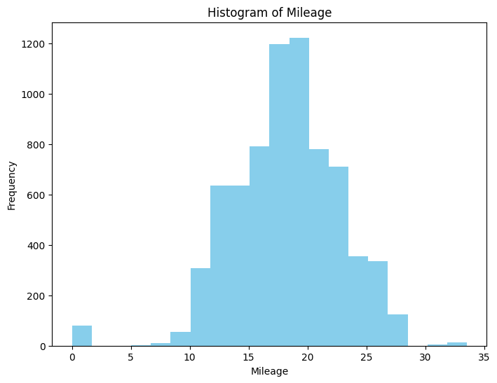

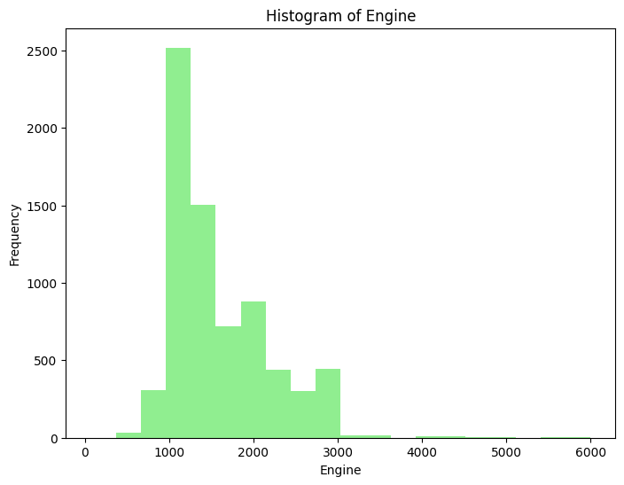

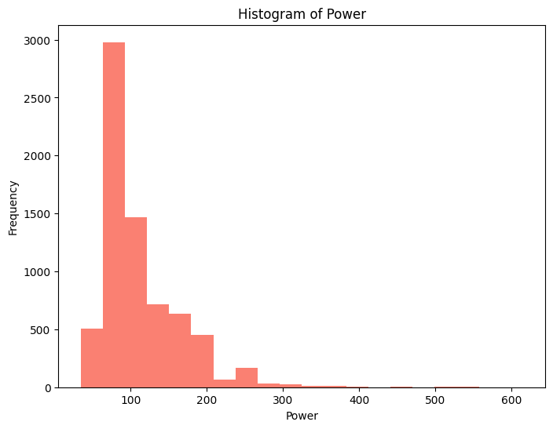

```python
import re
import numpy as np

# Define a function to remove non-digit characters
def remove_non_digits(text):
    if pd.isna(text):
        return np.nan
    else:
        # Remove non-digit characters except for '.'
        return re.sub(r'[^0-9.]', '', str(text))

# Convert missing values to NaN
data.replace('', np.nan, inplace=True)

# Apply the function to the specified columns
data['Mileage'] = data['Mileage'].apply(remove_non_digits)
data['New_Price'] = data['New_Price'].apply(remove_non_digits)
data['Power'] = data['Power'].apply(remove_non_digits)
data['Engine'] = data['Engine'].apply(remove_non_digits)

# Convert 'Power' column to float type
data['Power'] = pd.to_numeric(data['Power'], errors='coerce')

# Plot histograms for Mileage, Engine, and Power
plt.figure(figsize=(8, 6))
plt.hist(data['Mileage'].dropna().astype(float), bins=20, color='skyblue')
plt.title('Histogram of Mileage')
plt.xlabel('Mileage')
plt.ylabel('Frequency')
plt.show()

plt.figure(figsize=(8, 6))
plt.hist(data['Engine'].dropna().astype(float), bins=20, color='lightgreen')
plt.title('Histogram of Engine')
plt.xlabel('Engine')
plt.ylabel('Frequency')
plt.show()

plt.figure(figsize=(8, 6))
plt.hist(data['Power'].dropna().astype(float), bins=20, color='salmon')
plt.title('Histogram of Power')
plt.xlabel('Power')
plt.ylabel('Frequency')
plt.show()
```

```python
data.shape
```

```
(7253, 14)
```

```python
data.head()
```

|  | S.No. | Name | Location | Year | Kilometers_Driven | Fuel_Type | Transmission | Owner_Type | Mileage | Engine | Power | Seats | New_Price | Price |
| --- | --- | --- | --- | --- | --- | --- | --- | --- | --- | --- | --- | --- | --- | --- |
| 0 | 0 | Maruti Wagon R LXI CNG | Mumbai | 2010 | 72000 | CNG | Manual | First | 26.6 | 998 | 58.16 | 5.0 | NaN | 1.75 |
| 1 | 1 | Hyundai Creta 1.6 CRDi SX Option | Pune | 2015 | 41000 | Diesel | Manual | First | 19.67 | 1582 | 126.20 | 5.0 | NaN | 12.50 |
| 2 | 2 | Honda Jazz V | Chennai | 2011 | 46000 | Petrol | Manual | First | 18.2 | 1199 | 88.70 | 5.0 | 8.61 | 4.50 |
| 3 | 3 | Maruti Ertiga VDI | Chennai | 2012 | 87000 | Diesel | Manual | First | 20.77 | 1248 | 88.76 | 7.0 | NaN | 6.00 |
| 4 | 4 | Audi A4 New 2.0 TDI Multitronic | Coimbatore | 2013 | 40670 | Diesel | Automatic | Second | 15.2 | 1968 | 140.80 | 5.0 | NaN | 17.74 |

```python
print(type(data))
```

```
<class 'pandas.core.frame.DataFrame'>
```

```python
data.dtypes
```

```
S.No.                  int64
Name                  object
Location              object
Year                   int64
Kilometers_Driven      int64
Fuel_Type             object
Transmission          object
Owner_Type            object
Mileage               object
Engine                object
Power                float64
Seats                float64
New_Price             object
Price                float64
dtype: object
```

```python
data.describe()
```

|  | S.No. | Year | Kilometers_Driven | Power | Seats | Price |
| --- | --- | --- | --- | --- | --- | --- |
| count | 7253.000000 | 7253.000000 | 7.253000e+03 | 7078.000000 | 7200.000000 | 6019.000000 |
| mean | 3626.000000 | 2013.365366 | 5.869906e+04 | 112.765214 | 5.279722 | 9.479468 |
| std | 2093.905084 | 3.254421 | 8.442772e+04 | 53.493553 | 0.811660 | 11.187917 |
| min | 0.000000 | 1996.000000 | 1.710000e+02 | 34.200000 | 0.000000 | 0.440000 |
| 25% | 1813.000000 | 2011.000000 | 3.400000e+04 | 75.000000 | 5.000000 | 3.500000 |
| 50% | 3626.000000 | 2014.000000 | 5.341600e+04 | 94.000000 | 5.000000 | 5.640000 |
| 75% | 5439.000000 | 2016.000000 | 7.300000e+04 | 138.100000 | 5.000000 | 9.950000 |
| max | 7252.000000 | 2019.000000 | 6.500000e+06 | 616.000000 | 10.000000 | 160.000000 |

```python
# Check the datatypes of each column. Hint: Use info() method
data.info()
```

```
<class 'pandas.core.frame.DataFrame'>
RangeIndex: 7253 entries, 0 to 7252
Data columns (total 14 columns):
 #   Column             Non-Null Count  Dtype
---  ------             --------------  -----
 0   S.No.              7253 non-null   int64
 1   Name               7253 non-null   object
 2   Location           7253 non-null   object
 3   Year               7253 non-null   int64
 4   Kilometers_Driven  7253 non-null   int64
 5   Fuel_Type          7253 non-null   object
 6   Transmission       7253 non-null   object
 7   Owner_Type         7253 non-null   object
 8   Mileage            7251 non-null   object
 9   Engine             7207 non-null   object
 10  Power              7078 non-null   float64
 11  Seats              7200 non-null   float64
 12  New_Price          1006 non-null   object
 13  Price              6019 non-null   float64
dtypes: float64(3), int64(3), object(8)
memory usage: 793.4+ KB
```

```python
data.isnull().sum()
```

```
S.No.                   0
Name                    0
Location                0
Year                    0
Kilometers_Driven       0
Fuel_Type               0
Transmission            0
Owner_Type              0
Mileage                 2
Engine                 46
Power                 175
Seats                  53
New_Price            6247
Price                1234
dtype: int64
```

```python
feature_names = data.columns
print("Feature names:")
print(feature_names)
```

```
Feature names:
Index(['S.No.', 'Name', 'Location', 'Year', 'Kilometers_Driven', 'Fuel_Type',
       'Transmission', 'Owner_Type', 'Mileage', 'Engine', 'Power', 'Seats',
       'New_Price', 'Price'],
      dtype='object')
```

```python
# Convert 'Mileage' column to numeric type
data['Mileage'] = pd.to_numeric(data['Mileage'], errors='coerce')

# Convert 'Engine' column to numeric type
data['Engine'] = pd.to_numeric(data['Engine'], errors='coerce')
```

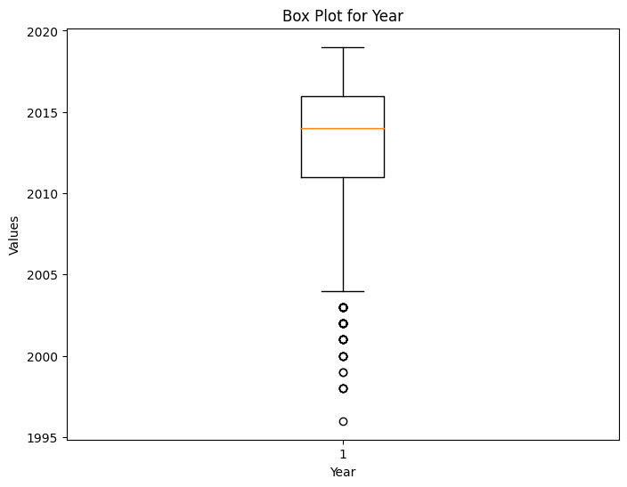

```
Percentage of outliers for Year: 0.80%
```

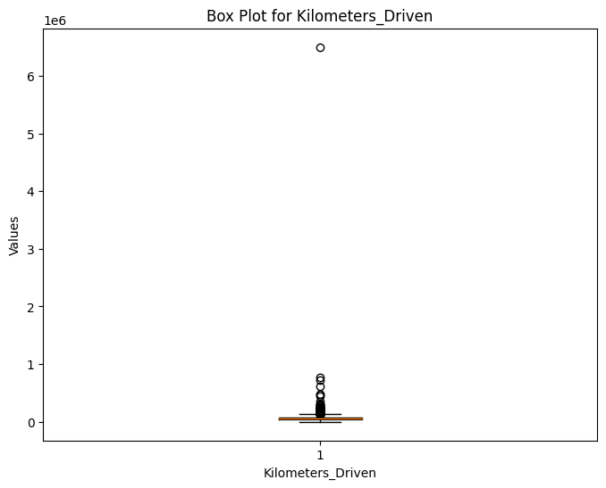

```
Percentage of outliers for Kilometers_Driven: 3.56%
```

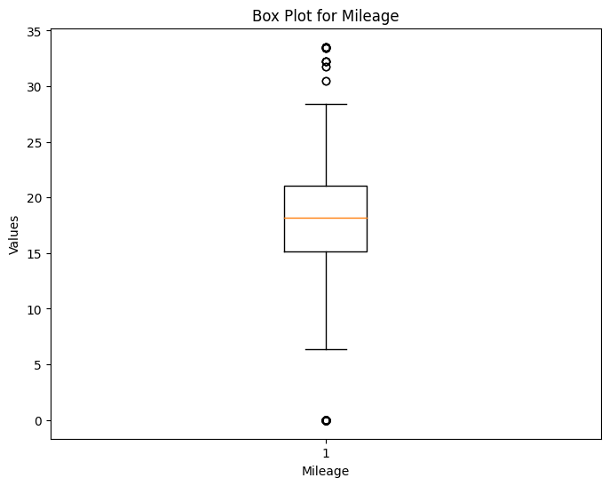

```
Percentage of outliers for Mileage: 1.37%
```

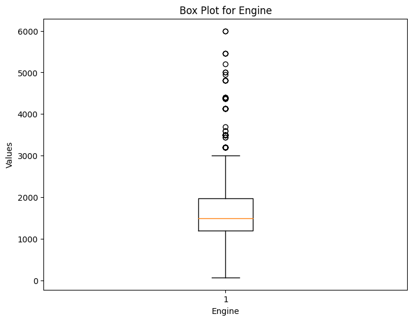

```
Percentage of outliers for Engine: 0.90%
```

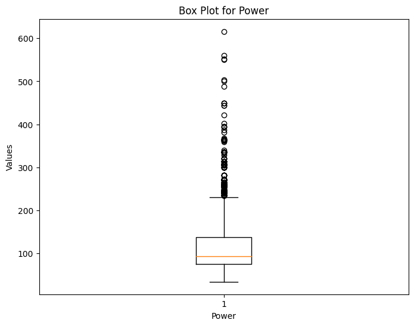

```
Percentage of outliers for Power: 3.86%
```

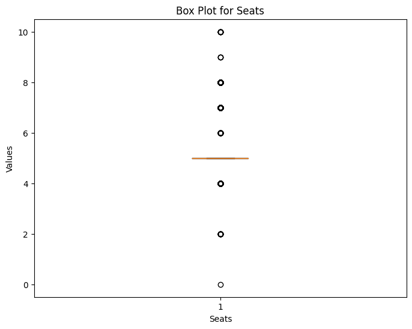

```
Percentage of outliers for Seats: 16.01%
```

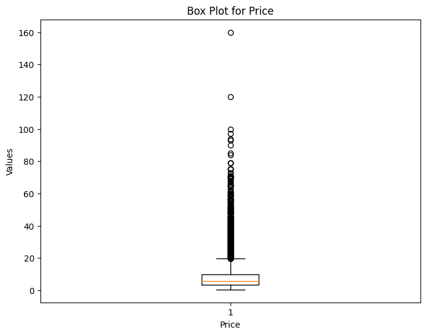

```
Percentage of outliers for Price: 11.93%
```

```python
import pandas as pd
import matplotlib.pyplot as plt

# List of features to create box plots for
features = ['Year', 'Kilometers_Driven', 'Mileage', 'Engine', 'Power', 'Seats', 'Price']

# Create individual box plots for each feature and calculate percentage of outliers
for feature in features:
    plt.figure(figsize=(8, 6))

    # Drop NA values to avoid errors in plotting
    feature_values = data[feature].dropna()

    # Filter out any non-numeric values
    feature_values = feature_values[feature_values.apply(lambda x: isinstance(x, (int, float)))]

    # Check if there are any numeric values present
    if feature_values.empty:
        print(f"No numeric values found for {feature}")
        continue

    # Create the box plot
    plt.boxplot(feature_values)
    plt.title(f"Box Plot for {feature}")
    plt.xlabel(feature)
    plt.ylabel("Values")
    plt.show()

    # Calculate the percentage of outliers
    Q1 = feature_values.quantile(0.25)
    Q3 = feature_values.quantile(0.75)
    IQR = Q3 - Q1
    lower_bound = Q1 - 1.5 * IQR
    upper_bound = Q3 + 1.5 * IQR
    num_outliers = len(feature_values[(feature_values < lower_bound) | (feature_values > upper_bound)])
    total_data_points = len(feature_values)

    # Check if total_data_points is zero to avoid ZeroDivisionError
    if total_data_points != 0:
        percentage_outliers = (num_outliers / total_data_points) * 100
    else:
        percentage_outliers = 0

    # Print the percentage of outliers
    print(f"Percentage of outliers for {feature}: {percentage_outliers:.2f}%")
```

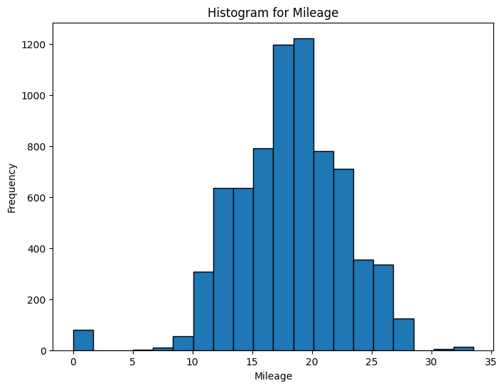

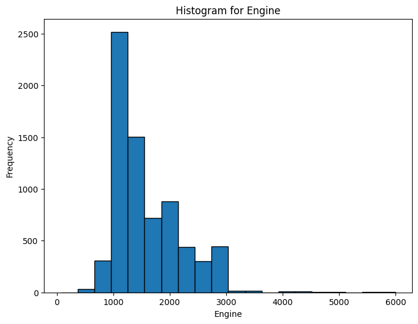

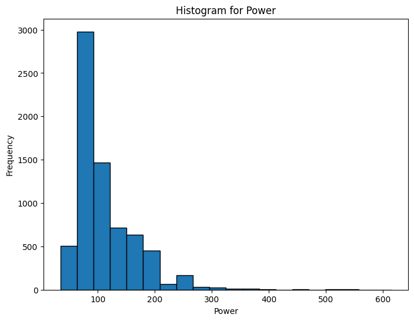

```python
import pandas as pd
import matplotlib.pyplot as plt

# List of features to create histograms for
features = ['Mileage', 'Engine', 'Power']

# Create individual histograms for each feature
for feature in features:
    plt.figure(figsize=(8, 6))

    # Drop NA values to avoid errors in plotting
    feature_values = data[feature].dropna()

    # Filter out any non-numeric values
    feature_values = feature_values[feature_values.apply(lambda x: isinstance(x, (int, float)))]

    # Check if there are any numeric values present
    if feature_values.empty:
        print(f"No numeric values found for {feature}")
        continue

    # Create the histogram
    plt.hist(feature_values, bins=20, edgecolor='black')
    plt.title(f"Histogram for {feature}")
    plt.xlabel(feature)
    plt.ylabel("Frequency")
    plt.show()
```

```python
data.head()
```

|  | S.No. | Name | Location | Year | Kilometers_Driven | Fuel_Type | Transmission | Owner_Type | Mileage | Engine | Power | Seats | New_Price | Price |
| --- | --- | --- | --- | --- | --- | --- | --- | --- | --- | --- | --- | --- | --- | --- |
| 0 | 0 | Maruti Wagon R LXI CNG | Mumbai | 2010 | 72000 | CNG | Manual | First | 26.60 | 998.0 | 58.16 | 5.0 | NaN | 1.75 |
| 1 | 1 | Hyundai Creta 1.6 CRDi SX Option | Pune | 2015 | 41000 | Diesel | Manual | First | 19.67 | 1582.0 | 126.20 | 5.0 | NaN | 12.50 |
| 2 | 2 | Honda Jazz V | Chennai | 2011 | 46000 | Petrol | Manual | First | 18.20 | 1199.0 | 88.70 | 5.0 | 8.61 | 4.50 |
| 3 | 3 | Maruti Ertiga VDI | Chennai | 2012 | 87000 | Diesel | Manual | First | 20.77 | 1248.0 | 88.76 | 7.0 | NaN | 6.00 |
| 4 | 4 | Audi A4 New 2.0 TDI Multitronic | Coimbatore | 2013 | 40670 | Diesel | Automatic | Second | 15.20 | 1968.0 | 140.80 | 5.0 | NaN | 17.74 |

**Observations and Insights: Data preprocessing is an essential step in the data analysis and machine learning pipeline. It involves cleaning and transforming the raw data to make it suitable for analysis and modeling. In the case of the used cars dataset, there might be several data treatments and preprocessing steps required. Some common ones are:

1. Handling Missing Values: Check for missing values in each column and decide on an appropriate strategy to deal with them. You can either remove rows with missing values, fill missing values using imputation techniques (e.g., mean, median, mode), or use more advanced methods like interpolation or regression-based imputation.
2. Encoding Categorical Variables: Convert categorical variables (e.g., Fuel_Type, Transmission, Owner_Type) into numerical format so that they can be used in machine learning models. Common techniques for encoding include one-hot encoding or label encoding.
3. Feature Scaling: Scale numerical features to bring them to a similar scale, especially if they have different units or magnitudes. Common scaling techniques include Min-Max scaling or Standardization (Z-score normalization).
4. Handling Outliers: Identify and handle outliers in the dataset, especially in numerical features like Kilometers_Driven, Mileage, Engine, Power, Seats, New_price, and Price. Outliers can impact the model's performance, so you may choose to remove or transform them.
5. Feature Engineering: Create new features based on domain knowledge or feature transformations that might better represent the underlying patterns in the data. For example, you can calculate the age of the car from the 'Year' feature or create a feature representing the car's price range (low, medium, high) based on Price.
6. Dealing with Imbalanced Data: If the target variable (Price) is imbalanced (e.g., skewed towards certain price ranges), consider using techniques like oversampling, undersampling, or using specialized algorithms designed for imbalanced data.
7. Handling Data Types: Ensure that each feature has the appropriate data type (e.g., numerical, categorical) for analysis and modeling.
8. Removing Irrelevant Features: If certain features do not contribute much to the target variable or are not relevant to the problem, consider removing them from the dataset.
9. Handling Multi-collinearity: Check for multicollinearity among features and handle it if it exists to avoid redundant information in the model.

We can observe that `S.No.` has no null values. Also the number of unique values are equal to the number of observations. So, `S.No.` looks like an index for the data entry and such a column would not be useful in providing any predictive power for our analysis. Hence, it can be dropped.

```python
# Remove S.No. column from data. Hint: Use inplace = True
data.drop('S.No.', axis=1, inplace=True)
```

## **EDA**

### **Summary statistics of numerical variables**

#### Explore basic summary statistics of numeric variables using describe() method.

**Observations and Insights: Count: The number of non-null values for each feature. For example, there are 7253 non-null values for the 'S.No.' and 'Year' columns, 7207 non-null values for the 'Engine' column, and so on. Mean: The average value for each feature. For example, the average 'Year' in the dataset is approximately 2013.37, and the average 'Kilometers_Driven' is approximately 58699.06. Standard Deviation (std): A measure of how much the values vary from the mean for each feature. It provides information about the spread or dispersion of the data. For example, the standard deviation for 'Year' is approximately 3.25, and for 'Kilometers_Driven' is approximately 84427.72. Minimum (min): The minimum value for each feature. For example, the minimum 'Year' in the dataset is 1996, and the minimum 'Kilometers_Driven' is 171. 25th Percentile (25%): Also known as the first quartile (Q1), this represents the value below which 25% of the data falls. For example, 25% of the 'Year' values are below 2011, and 25% of the 'Kilometers_Driven' values are below 34000. 50th Percentile (50%): Also known as the median, this represents the value below which 50% of the data falls. For example, the median 'Year' is 2014, and the median 'Kilometers_Driven' is 53416.75th Percentile (75%): Also known as the third quartile (Q3), this represents the value below which 75% of the data falls. For example, 75% of the 'Year' values are below 2016, and 75% of the 'Kilometers_Driven' values are below 73000. Maximum (max): The maximum value for each feature. For example, the maximum 'Year' is 2019, and the maximum 'Kilometers_Driven' is 6,500,000. These statistics provide valuable insights into the distribution and characteristics of each feature in the dataset. They can help in understanding the data and identifying potential outliers or data issues. However, further analysis and data exploration are usually required to gain a deeper understanding of the dataset and to make informed decisions for data preprocessing and modeling.**

### **Summary statistics of all categorical variables and the number of unique observations in each category**

#### Explore basic summary statistics of categorical variables use=ing the argument include = ['object']

**Number of unique observations in each category**

```python
cat_cols = data.select_dtypes(include=['object']).columns

for column in cat_cols:
    print("For column:", column)
    print(data[column].value_counts())
    print('-' * 50)
```

```
For column: Name
Mahindra XUV500 W8 2WD                  55
Maruti Swift VDI                        49
Maruti Swift Dzire VDI                  42
Honda City 1.5 S MT                     39
Maruti Swift VDI BSIV                   37
                                        ..
Chevrolet Beat LT Option                 1
Skoda Rapid 1.6 MPI AT Elegance Plus     1
Ford EcoSport 1.5 TDCi Ambiente          1
Hyundai i10 Magna 1.1 iTech SE           1
Hyundai Elite i20 Magna Plus             1
Name: Name, Length: 2041, dtype: int64
--------------------------------------------------
For column: Location
Mumbai        949
Hyderabad     876
Coimbatore    772
Kochi         772
Pune          765
Delhi         660
Kolkata       654
Chennai       591
Jaipur        499
Bangalore     440
Ahmedabad     275
Name: Location, dtype: int64
--------------------------------------------------
For column: Fuel_Type
Diesel      3852
Petrol      3325
CNG           62
LPG           12
Electric       2
Name: Fuel_Type, dtype: int64
--------------------------------------------------
For column: Transmission
Manual       5204
Automatic    2049
Name: Transmission, dtype: int64
--------------------------------------------------
For column: Owner_Type
First             5952
Second            1152
Third              137
Fourth & Above      12
Name: Owner_Type, dtype: int64
--------------------------------------------------
For column: New_Price
63.71    6
95.13    6
4.78     6
33.36    6
44.28    5
        ..
6.83     1
9.09     1
7.17     1
11.77    1
18.16    1
Name: New_Price, Length: 625, dtype: int64
--------------------------------------------------
```

#### **Observations and Insights: Name: The column 'Name' contains 2041 unique car names. The most frequent car model in the dataset is "Mahindra XUV500 W8 2WD" with 55 occurrences, followed by "Maruti Swift VDI" with 49 occurrences. There are several car models with only one occurrence, indicating a wide variety of car models present in the dataset. Location: The column 'Location' represents the cities or regions where the used cars are being sold. Mumbai has the highest number of entries (949) in the dataset, followed by Hyderabad and Coimbatore with 876 and 772 entries, respectively. The data seems to be distributed across multiple locations. Fuel_Type: The column 'Fuel_Type' indicates the type of fuel used by the vehicles. Diesel and Petrol are the most common fuel types, with 3852 and 3325 entries, respectively. CNG and LPG are less common, with 62 and 12 entries, respectively. There are only two entries for Electric cars. Transmission: The column 'Transmission' represents the type of transmission used in the vehicles. Manual transmission is more prevalent, with 5204 entries, while automatic transmission has 2049 entries. Manual transmission seems to be the dominant choice among the cars in the dataset. Owner_Type: The column 'Owner_Type' indicates the number of previous owners for each car. Most of the cars (5952) have 'First' owners, followed by 'Second' owners with 1152 entries. There are only a few cars with 'Third' or 'Fourth & Above' owners, indicating that the majority of the cars in the dataset have had one or two previous owners.**

**Check Kilometers_Driven extreme values**

```python
# Sort the dataset in 'descending' order using the feature 'Kilometers_Driven'
data.sort_values(by='Kilometers_Driven', ascending=False).head(10)
```

|  | Name | Location | Year | Kilometers_Driven | Fuel_Type | Transmission | Owner_Type | Mileage | Engine | Power | Seats | New_Price | Price |
| --- | --- | --- | --- | --- | --- | --- | --- | --- | --- | --- | --- | --- | --- |
| 2328 | BMW X5 xDrive 30d M Sport | Chennai | 2017 | 6500000 | Diesel | Automatic | First | 15.97 | 2993.0 | 258.00 | 5.0 | NaN | 65.00 |
| 340 | Skoda Octavia Ambition Plus 2.0 TDI AT | Kolkata | 2013 | 775000 | Diesel | Automatic | First | 19.30 | 1968.0 | 141.00 | 5.0 | NaN | 7.50 |
| 1860 | Volkswagen Vento Diesel Highline | Chennai | 2013 | 720000 | Diesel | Manual | First | 20.54 | 1598.0 | 103.60 | 5.0 | NaN | 5.90 |
| 358 | Hyundai i10 Magna 1.2 | Chennai | 2009 | 620000 | Petrol | Manual | First | 20.36 | 1197.0 | 78.90 | 5.0 | NaN | 2.70 |
| 2823 | Volkswagen Jetta 2013-2015 2.0L TDI Highline AT | Chennai | 2015 | 480000 | Diesel | Automatic | First | 16.96 | 1968.0 | 138.03 | 5.0 | NaN | 13.00 |
| 3092 | Honda City i VTEC SV | Kolkata | 2015 | 480000 | Petrol | Manual | First | 17.40 | 1497.0 | 117.30 | 5.0 | NaN | 5.00 |
| 4491 | Hyundai i20 Magna Optional 1.2 | Bangalore | 2013 | 445000 | Petrol | Manual | First | 18.50 | 1197.0 | 82.90 | 5.0 | NaN | 4.45 |
| 6921 | Maruti Swift Dzire Tour LDI | Jaipur | 2012 | 350000 | Diesel | Manual | First | 23.40 | 1248.0 | 74.00 | 5.0 | NaN | NaN |
| 3649 | Tata Indigo LS | Jaipur | 2008 | 300000 | Diesel | Manual | First | 17.00 | 1405.0 | 70.00 | 5.0 | NaN | 1.00 |
| 1528 | Toyota Innova 2.5 G (Diesel) 8 Seater BS IV | Hyderabad | 2005 | 299322 | Diesel | Manual | First | 12.80 | 2494.0 | 102.00 | 8.0 | NaN | 4.00 |

#### **Observations and Insights: Based on the provided data, here are some observations and insights: Name and Location: The data contains information about various car models along with their corresponding locations where they are being sold. Each row represents a specific car listing. Year: The 'Year' column represents the manufacturing year of the cars. The data includes cars from 2005 to 2017. Kilometers_Driven: The 'Kilometers_Driven' column indicates the total kilometers driven by each car. Some entries have exceptionally high values, such as 6,500,000, indicating that some cars have been driven extensively. Fuel_Type and Transmission: The 'Fuel_Type' column denotes the type of fuel used by the cars (e.g., Diesel, Petrol). The 'Transmission' column indicates whether the car has a manual or automatic transmission. Owner_Type: The 'Owner_Type' column describes the number of previous owners for each car, categorized as 'First', 'Second', 'Third', or 'Fourth & Above'. Mileage, Engine, Power, and Seats: These columns represent the mileage (in km/l), engine displacement (in cc), power (in bhp), and number of seats in each car, respectively. New_price and Price: The 'New_price' column seems to have some missing values (NaN). It could represent the original price of the cars when they were new. The 'Price' column might represent the current selling price of the used cars. Some entries also have missing values for 'Price'. Observations: The data contains various car models with different features and attributes. Some cars have missing values for 'New_price' and 'Price', which could be due to incomplete information or unavailability of data. The data seems to be from different locations, indicating that it covers a wide geographic area. Insights: The data can be useful for various analyses, such as understanding the relationship between car attributes and their prices, identifying popular car models in specific locations, or exploring the impact of kilometers driven on car prices. However, due to missing values and potential outliers in the 'Kilometers_Driven' column, data pre-processing and handling of missing values would be essential before any further analysis or modeling. To gain more meaningful insights and make data-driven decisions, further data cleaning, exploratory data analysis (EDA), and statistical analysis would be necessary. Additionally, handling missing values and dealing with outliers in the 'Kilometers_Driven' and 'Price' columns can significantly impact the results of any analysis or modeling tasks.**

In the first row, a car manufactured as recently as 2017 having been driven 6500000 km is almost impossible. It can be considered as data entry error and so we can remove this value/entry from data.

```python
# Removing the 'row' at index 2328 from the data. Hint: use the argument inplace=True
data.drop(index=2328, inplace=True)
```

**Checking Mileage extreme values**

```python
# Sort the dataset in 'ascending' order using the feature 'Mileage'
data.sort_values(by='Mileage').head(10)
```

|  | Name | Location | Year | Kilometers_Driven | Fuel_Type | Transmission | Owner_Type | Mileage | Engine | Power | Seats | New_Price | Price |
| --- | --- | --- | --- | --- | --- | --- | --- | --- | --- | --- | --- | --- | --- |
| 2597 | Hyundai Santro Xing XP | Pune | 2007 | 70000 | Petrol | Manual | First | 0.0 | 1086.0 | NaN | 5.0 | NaN | 1.12 |
| 2343 | Hyundai Santro AT | Hyderabad | 2006 | 74483 | Petrol | Automatic | First | 0.0 | 999.0 | NaN | 5.0 | NaN | 2.30 |
| 5270 | Honda City 1.5 GXI | Bangalore | 2002 | 53000 | Petrol | Manual | Second | 0.0 | NaN | NaN | NaN | NaN | 1.85 |
| 424 | Volkswagen Jetta 2007-2011 1.9 L TDI | Hyderabad | 2010 | 42021 | Diesel | Manual | First | 0.0 | 1968.0 | NaN | 5.0 | NaN | 5.45 |
| 6857 | Land Rover Freelander 2 TD4 SE | Mumbai | 2011 | 87000 | Diesel | Automatic | First | 0.0 | 2179.0 | 115.0 | 5.0 | NaN | NaN |
| 443 | Hyundai Santro GLS I - Euro I | Coimbatore | 2012 | 50243 | Petrol | Manual | First | 0.0 | 1086.0 | NaN | 5.0 | NaN | 3.35 |
| 5119 | Hyundai Santro Xing XP | Kolkata | 2008 | 45500 | Petrol | Manual | Second | 0.0 | 1086.0 | NaN | 5.0 | NaN | 1.17 |
| 5022 | Land Rover Freelander 2 TD4 SE | Hyderabad | 2013 | 46000 | Diesel | Automatic | Second | 0.0 | 2179.0 | 115.0 | 5.0 | NaN | 26.00 |
| 5016 | Land Rover Freelander 2 TD4 HSE | Delhi | 2013 | 72000 | Diesel | Automatic | First | 0.0 | 2179.0 | 115.0 | 5.0 | NaN | 15.50 |
| 2542 | Hyundai Santro GLS II - Euro II | Bangalore | 2011 | 65000 | Petrol | Manual | Second | 0.0 | NaN | NaN | NaN | NaN | 3.15 |

#### **Observations**

- Mileage of cars can not be 0, so we should treat 0's as missing values. We will do it in the Feature Engineering part.

## **Univariate Analysis**

Univariate analysis is used to explore each variable in a data set, separately. It looks at the range of values, as well as the central tendency of the values. It can be done for both numerical and categorical variables.

## **1. Univariate Analysis - Numerical Data**

Histograms and box plots help to visualize and describe numerical data. We use box plot and histogram to analyse the numerical columns.

```python
# Let us write a function that will help us create a boxplot and histogram for any input numerical variable.
# This function takes the numerical column as the input and returns the boxplots and histograms for the variable.

def histogram_boxplot(feature, figsize = (15, 10), bins = None):

    """ Boxplot and histogram combined

    feature: 1-d feature array

    figsize: size of fig (default (9, 8))

    bins: number of bins (default None / auto)

    """
    f2, (ax_box2, ax_hist2) = plt.subplots(nrows = 2, # Number of rows of the subplot grid = 2
                                           sharex = True, # X-axis will be shared among all subplots
                                           gridspec_kw = {"height_ratios": (.25, .75)},
                                           figsize = figsize
                                           ) # Creating the 2 subplots

    sns.boxplot(feature, ax = ax_box2, showmeans = True, color = 'violet') # Boxplot will be created and a symbol will indicate the mean value of the column

    sns.distplot(feature, kde = F, ax = ax_hist2, bins = bins, palette = "winter") if bins else sns.distplot(feature, kde = False, ax = ax_hist2) # For histogram

    ax_hist2.axvline(np.mean(feature), color = 'green', linestyle = '--') # Add mean to the histogram

    ax_hist2.axvline(np.median(feature), color = 'black', linestyle = '-') # Add median to the histogram
```

**Let us plot histogram and box-plot for the feature 'Kilometers_Driven' to understand the distribution and outliers, if any.**

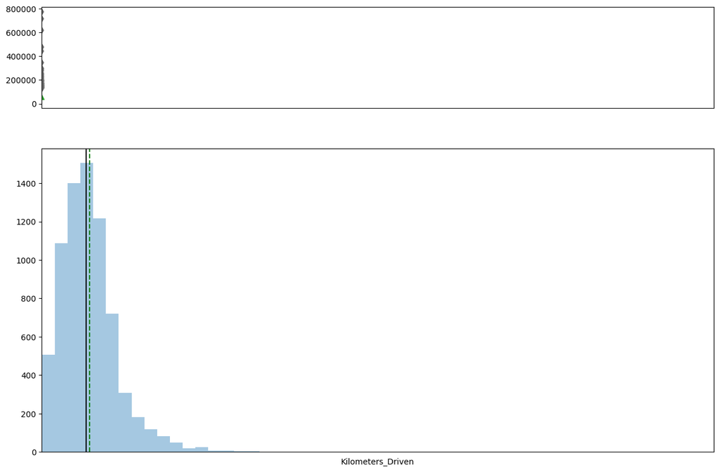

```python
# Plot histogram and box-plot for 'Kilometers_Driven'
histogram_boxplot(data['Kilometers_Driven'])
```

-Kilometers_Driven is highly right-skewed. We can use a log transformation of the 'Kilometers_Driven' feature to reduce or remove the right-skewness. Log transformation is a common technique used to stabilize variance, reduce skewness, and make the data more suitable for certain statistical analyses and modeling techniques. In a right-skewed distribution, the majority of the data is concentrated on the left side, and there are a few extreme values on the right side that cause the tail to extend to the right. Log transformation can help in reducing the impact of extreme values and bring the distribution closer to a normal (Gaussian) distribution. Model Performance: Some machine learning models, like linear regression, assume that the data is normally distributed or at least less skewed. Skewed data can lead to biased model predictions and suboptimal performance. Interpretability: Skewed data can make it challenging to interpret the results and relationships between variables. Log-transforming the data can make the relationships more interpretable. Outlier Impact: Skewed data can exaggerate the impact of outliers, leading to overfitting or unstable models. Log transformation can reduce the influence of extreme values. Statistical Tests: Skewed data can violate the assumptions of some statistical tests, affecting the validity of the results. While log transformation is useful in many cases, it's not always necessary or appropriate. Some models and algorithms can handle skewed data well, or the skewness might be informative for the problem at hand. In such cases, you might decide to keep the skewed data as is. The decision to use log transformation or keep the data skewed depends on the specific context, the nature of the data, and the goals of the analysis or modeling. Always perform exploratory data analysis (EDA) to understand the data distribution and the impact of transformations before making a decision.

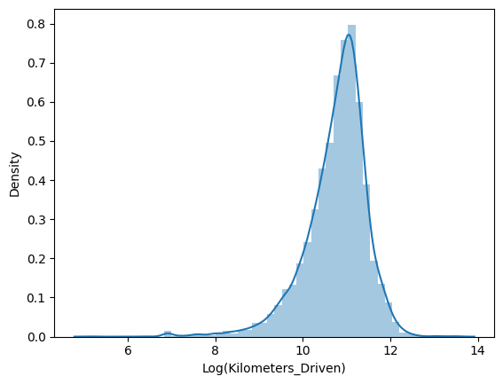

```python
# Log transformation of the feature 'Kilometers_Driven'
sns.distplot(np.log(data["Kilometers_Driven"]), axlabel = "Log(Kilometers_Driven)");
```

**Observations and Insights: We can use a log transformation of the 'Kilometers_Driven' feature to reduce or remove the right-skewness. Log transformation is a common technique used to stabilize variance, reduce skewness, and make the data more suitable for certain statistical analyses and modeling techniques. In a right-skewed distribution, the majority of the data is concentrated on the left side, and there are a few extreme values on the right side that cause the tail to extend to the right. Log transformation can help in reducing the impact of extreme values and bring the distribution closer to a normal (Gaussian) distribution. Model Performance: Some machine learning models, like linear regression, assume that the data is normally distributed or at least less skewed. Skewed data can lead to biased model predictions and suboptimal performance. Interpretability: Skewed data can make it challenging to interpret the results and relationships between variables. Log-transforming the data can make the relationships more interpretable. Outlier Impact: Skewed data can exaggerate the impact of outliers, leading to overfitting or unstable models. Log transformation can reduce the influence of extreme values. Statistical Tests: Skewed data can violate the assumptions of some statistical tests, affecting the validity of the results. While log transformation is useful in many cases, it's not always necessary or appropriate. Some models and algorithms can handle skewed data well, or the skewness might be informative for the problem at hand. In such cases, you might decide to keep the skewed data as is. The decision to use log transformation or keep the data skewed depends on the specific context, the nature of the data, and the goals of the analysis or modeling. Always perform exploratory data analysis (EDA) to understand the data distribution and the impact of transformations before making a decision.**

```python
# We can add a transformed kilometers_driven feature in data
data["kilometers_driven_log"] = np.log(data["Kilometers_Driven"])
```

**Note:** Like Kilometers_Driven, the distribution of Price is also highly skewed, we can use log transformation on this column to see if that helps normalize the distribution. And add the transformed variable into the dataset. You can name the variable as **'price_log'**.

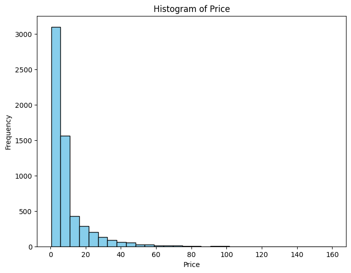

```python
# Plot histogram and box-plot for 'Price'
import matplotlib.pyplot as plt
import pandas as pd
import matplotlib.pyplot as plt

# Assuming you have already loaded the 'data' DataFrame

# Plot histogram for 'Price'
plt.figure(figsize=(8, 6))
plt.hist(data['Price'], bins=30, color='skyblue', edgecolor='black')
plt.xlabel('Price')
plt.ylabel('Frequency')
plt.title('Histogram of Price')
plt.show()
```

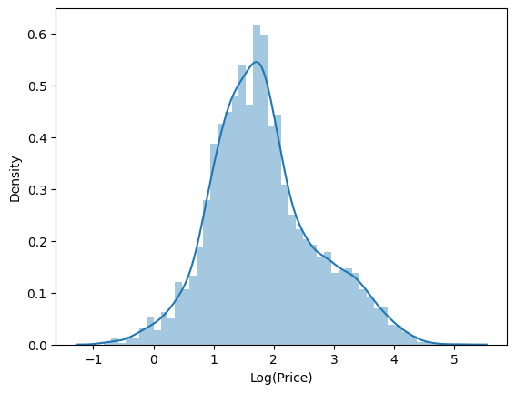

```python
sns.distplot(np.log(data["Price"]), axlabel = "Log(Price)");
```

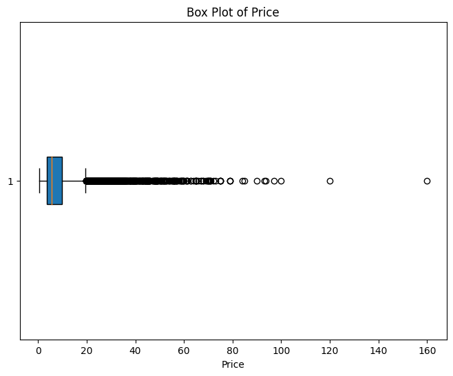

```python
# Log transformation of the feature 'Price'
import matplotlib.pyplot as plt

# Plot box plot for 'Price'
plt.figure(figsize=(8, 6))
plt.boxplot(data['Price'].dropna(), vert=False, patch_artist=True)
plt.xlabel('Price')
plt.title('Box Plot of Price')
plt.show()
```

```python
# We can Add a transformed Price feature in data
import numpy as np

# Adding Log-Price as a new feature
data['Log_Price'] = np.log(data['Price'].dropna())

# Print the first few rows of the DataFrame to verify the new column
print(data.head())
```

```
                               Name    Location  Year  Kilometers_Driven  \
0            Maruti Wagon R LXI CNG      Mumbai  2010              72000
1  Hyundai Creta 1.6 CRDi SX Option        Pune  2015              41000
2                      Honda Jazz V     Chennai  2011              46000
3                 Maruti Ertiga VDI     Chennai  2012              87000
4   Audi A4 New 2.0 TDI Multitronic  Coimbatore  2013              40670

  Fuel_Type Transmission Owner_Type  Mileage  Engine   Power  Seats New_Price  \
0       CNG       Manual      First    26.60   998.0   58.16    5.0       NaN
1    Diesel       Manual      First    19.67  1582.0  126.20    5.0       NaN
2    Petrol       Manual      First    18.20  1199.0   88.70    5.0      8.61
3    Diesel       Manual      First    20.77  1248.0   88.76    7.0       NaN
4    Diesel    Automatic     Second    15.20  1968.0  140.80    5.0       NaN

   Price  kilometers_driven_log  Log_Price
0   1.75              11.184421   0.559616
1  12.50              10.621327   2.525729
2   4.50              10.736397   1.504077
3   6.00              11.373663   1.791759
4  17.74              10.613246   2.875822
```

```python
# Convert 'Mileage' column to numeric type
data['Mileage'] = pd.to_numeric(data['Mileage'], errors='coerce')

# Convert 'Engine' column to numeric type
data['Engine'] = pd.to_numeric(data['Engine'], errors='coerce')
```

```python
feature_names = data.columns
print("Feature names:")
print(feature_names)
```

```
Feature names:
Index(['Name', 'Location', 'Year', 'Kilometers_Driven', 'Fuel_Type',
       'Transmission', 'Owner_Type', 'Mileage', 'Engine', 'Power', 'Seats',
       'New_Price', 'Price', 'kilometers_driven_log', 'Log_Price'],
      dtype='object')
```

**Note:** Try plotting histogram and box-plot for different numerical features and understand how the data looks like.

[figure not shown]

```python
import pandas as pd
import numpy as np
import matplotlib.pyplot as plt
from sklearn.preprocessing import MinMaxScaler

# Load data from the CSV file
data = pd.read_csv("used_cars.csv")

# Features to transform and normalize
features = ['Year', 'Engine', 'Power', 'New_price', 'Kilometers_Driven']

# Log transformation and normalization
for feature in features:
    # Log transformation
    data[f'{feature}_log'] = np.log(data[feature].dropna())

    # Normalization using Min-Max scaling
    scaler = MinMaxScaler()
    data[f'{feature}_log_normalized'] = scaler.fit_transform(data[f'{feature}_log'].values.reshape(-1, 1))

# Features to plot histograms for
features_to_plot = ['Year', 'Kilometers_Driven', 'Mileage', 'Engine', 'Power', 'Seats', 'Price', 'Kilometers_Driven_log', 'New_price_log']

# Plot histograms
plt.figure(figsize=(12, 10))

for i, feature in enumerate(features_to_plot):
    plt.subplot(4, 3, i+1)
    plt.hist(data[feature].dropna(), bins=30, color='skyblue', edgecolor='black')
    plt.xlabel(feature)
    plt.ylabel('Frequency')

plt.tight_layout()
plt.show()
```

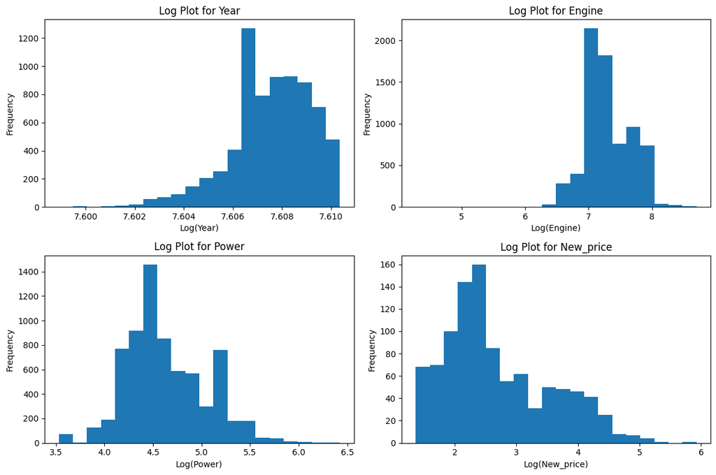

```python
import pandas as pd
import numpy as np
import matplotlib.pyplot as plt
from sklearn.preprocessing import MinMaxScaler

# Load data from the CSV file
data = pd.read_csv("used_cars.csv")

# Features to transform and normalize
features = ['Year', 'Engine', 'Power', 'New_price']

# Log transformation and normalization
for feature in features:
    # Log transformation
    data[f'{feature}_log'] = np.log(data[feature].dropna())

    # Normalization using Min-Max scaling
    scaler = MinMaxScaler()
    data[f'{feature}_log_normalized'] = scaler.fit_transform(data[f'{feature}_log'].values.reshape(-1, 1))

# Plot log plots
num_rows = 2
num_cols = 2

fig, axs = plt.subplots(num_rows, num_cols, figsize=(12, 8))

for i, feature in enumerate(features):
    row = i // num_cols
    col = i % num_cols

    axs[row, col].hist(data[f'{feature}_log'], bins=20)
    axs[row, col].set_title(f"Log Plot for {feature}")
    axs[row, col].set_xlabel(f"Log({feature})")
    axs[row, col].set_ylabel("Frequency")

plt.tight_layout()
plt.show()
```

```
Percentage of outliers for Year: 0.80%
Percentage of outliers for Kilometers_Driven: 3.56%
Percentage of outliers for Mileage: 1.37%
Percentage of outliers for Engine: 0.90%
Percentage of outliers for Power: 3.86%
Percentage of outliers for Seats: 16.00%
Percentage of outliers for New_price: 10.74%
Percentage of outliers for Price: 11.93%
Percentage of outliers for kilometers_driven_log: 3.85%
Percentage of outliers for Log_Price: 2.24%
```

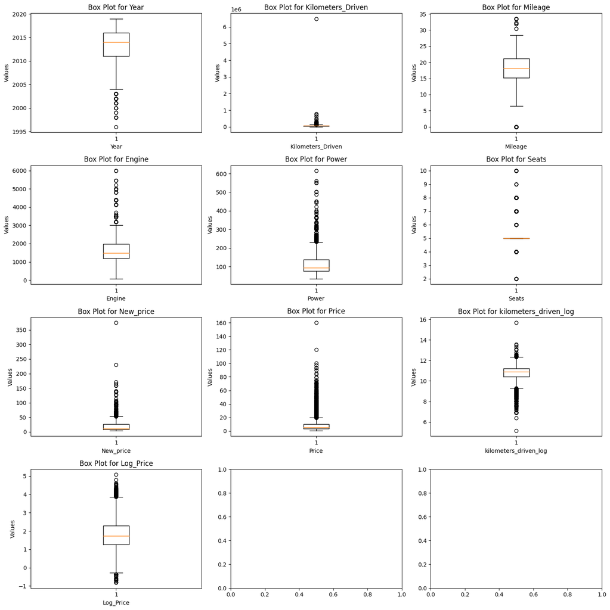

```python
import pandas as pd
import numpy as np
import matplotlib.pyplot as plt

# Load data from the CSV file
data = pd.read_csv("used_cars.csv")

# Adding Log transformation for 'Kilometers_Driven'
data['kilometers_driven_log'] = np.log(data['Kilometers_Driven'].dropna())

# Adding Log transformation for 'Price'
data['Log_Price'] = np.log(data['Price'].dropna())

# List of features to create box plots for
features = ['Year', 'Kilometers_Driven', 'Mileage', 'Engine', 'Power', 'Seats', 'New_price', 'Price', 'kilometers_driven_log', 'Log_Price']

# Create individual box plots for each feature and calculate percentage of outliers
num_rows = 4
num_cols = 3

fig, axs = plt.subplots(num_rows, num_cols, figsize=(15, 15))

for i, feature in enumerate(features):
    row = i // num_cols
    col = i % num_cols

    # Drop NA values to avoid errors in plotting
    feature_values = data[feature].dropna()

    # Create the box plot
    axs[row, col].boxplot(feature_values)
    axs[row, col].set_title(f"Box Plot for {feature}")
    axs[row, col].set_xlabel(feature)
    axs[row, col].set_ylabel("Values")

    # Calculate the percentage of outliers
    Q1 = feature_values.quantile(0.25)
    Q3 = feature_values.quantile(0.75)
    IQR = Q3 - Q1
    lower_bound = Q1 - 1.5 * IQR
    upper_bound = Q3 + 1.5 * IQR
    num_outliers = len(feature_values[(feature_values < lower_bound) | (feature_values > upper_bound)])
    total_data_points = len(feature_values)
    percentage_outliers = (num_outliers / total_data_points) * 100

    # Print the percentage of outliers
    print(f"Percentage of outliers for {feature}: {percentage_outliers:.2f}%")

plt.tight_layout()
plt.show()
```

**Observations and Insights for all the plots:Percentage of outliers for Year: 0.80% Percentage of outliers for Kilometers_Driven: 3.56% Percentage of outliers for Mileage: 1.37% Percentage of outliers for Engine: 0.90% Percentage of outliers for Power: 3.86% Percentage of outliers for Seats: 16.00% Percentage of outliers for New_price: 10.74% Percentage of outliers for Price: 11.93% Percentage of outliers for kilometers_driven_log: 3.85% Percentage of outliers for Log_Price: 2.24% Also, sometimes Log might be suitable and useful for removing skewness. Here we see that some of these Logs are good and some of them are not good**

## **Univariate analysis - Categorical Data**

```python
# Let us write a function that will help us create barplots that indicate the percentage for each category.
# This function takes the categorical column as the input and returns the barplots for the variable.

def perc_on_bar(z):
    '''
    plot
    feature: categorical feature
    the function won't work if a column is passed in hue parameter
    '''

    total = len(data[z]) # Length of the column

    plt.figure(figsize = (15, 5))

    ax = sns.countplot(data[z], palette = 'Paired', order = data[z].value_counts().index)

    for p in ax.patches:

        percentage = '{:.1f}%'.format(100 * p.get_height() / total) # Percentage of each class of the category

        x = p.get_x() + p.get_width() / 2 - 0.05 # Width of the plot

        y = p.get_y() + p.get_height()           # Hieght of the plot

        ax.annotate(percentage, (x, y), size = 12) # Annotate the percantage

    plt.show() # Show the plot
```

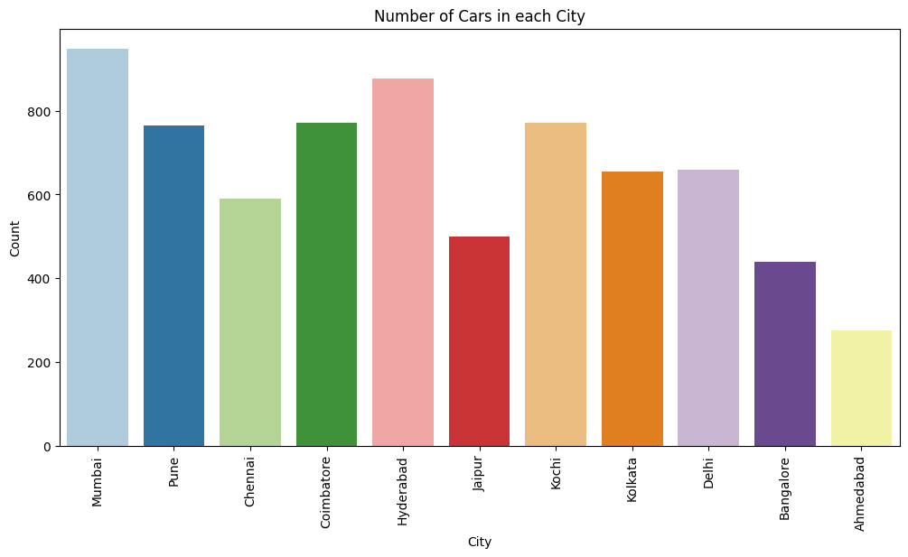

```python
# Bar Plot for 'Location'
# perc_on_bar('Location')
import pandas as pd
import matplotlib.pyplot as plt

# Load data from the CSV file
data = pd.read_csv("used_cars.csv")

# Plot the bar plot for 'Location'
plt.figure(figsize=(12, 6))
sns.countplot(x='Location', data=data, palette='Paired')
plt.title("Number of Cars in each City")
plt.xlabel("City")
plt.ylabel("Count")
plt.xticks(rotation=90)
plt.show()
```

**Observations and Insights from all plots: Mumbai has a large number of cars. The maximum number of used cars are related to the year of 2015. We have the maximum Fuel_type belongs to Diesle. Also, manual cars have highest number of cars in our datasheet. In the owner type, the first has a first rank among other parameters.**

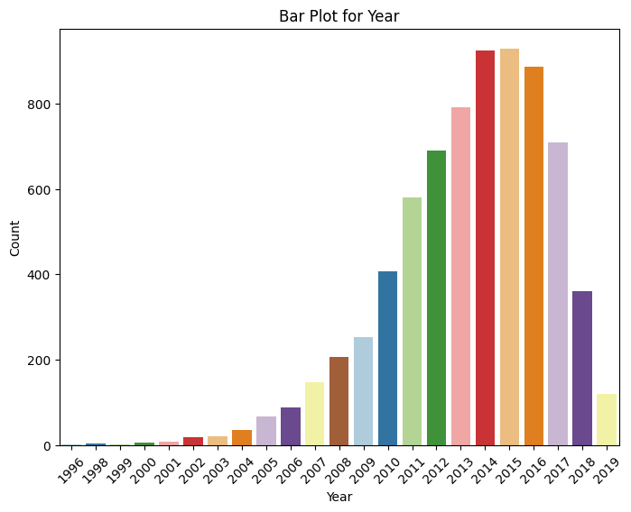

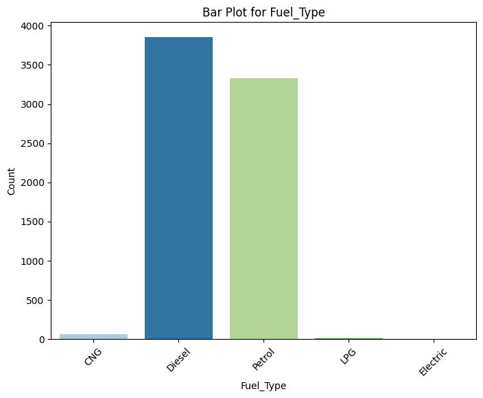

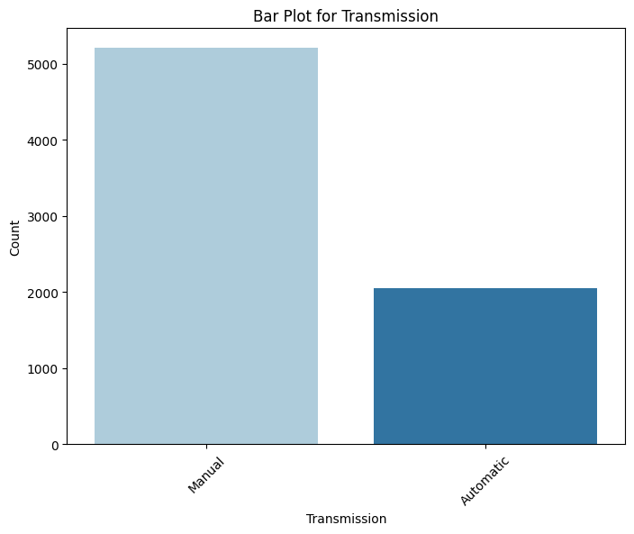

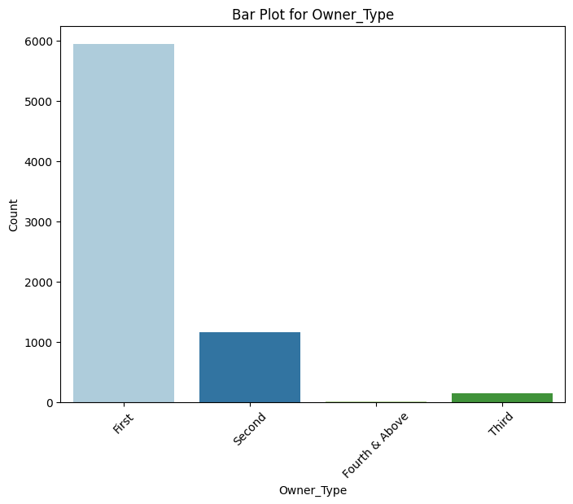

```python
import pandas as pd
import matplotlib.pyplot as plt
import seaborn as sns

# Load data from the CSV file
data = pd.read_csv("used_cars.csv")

# Define the list of variables to plot
variables = ['Year', 'Fuel_Type', 'Transmission', 'Owner_Type']

# Plot bar plots for each variable
for var in variables:
    plt.figure(figsize=(8, 6))
    sns.countplot(x=var, data=data, palette='Paired')
    plt.title(f"Bar Plot for {var}")
    plt.xlabel(var)
    plt.ylabel("Count")
    plt.xticks(rotation=45)
    plt.show()
```

## **Bivariate Analysis**

### **Scatter plot**

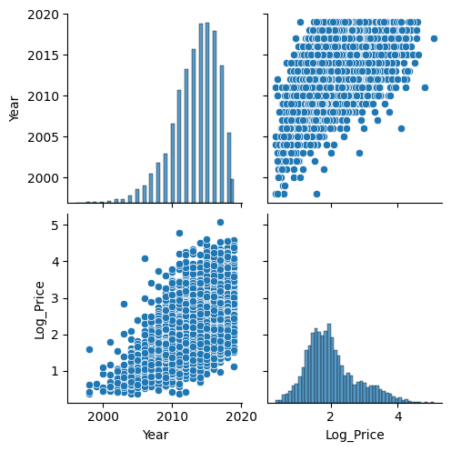

```python
# Let us plot pair plot for the variables 'year' and 'price_log'
# data.plot(x = 'price_log', y = 'Year', style = 'o')

import pandas as pd
import seaborn as sns
import matplotlib.pyplot as plt

# Load data from the CSV file
data = pd.read_csv("used_cars.csv")

# Calculate Log_Price and add it as a new column
data['Log_Price'] = data['Price'].apply(lambda x: np.log1p(x))

# Plot pair plot for 'Year' and 'Log_Price'
sns.pairplot(data=data, vars=['Year', 'Log_Price'])
plt.show()
```

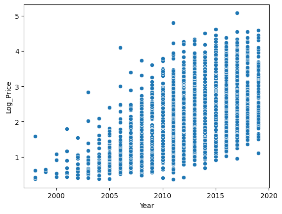

```python
import pandas as pd
import seaborn as sns
import matplotlib.pyplot as plt

# Load data from the CSV file
data = pd.read_csv("used_cars.csv")

# Calculate Log_Price and add it as a new column
data['Log_Price'] = data['Price'].apply(lambda x: np.log1p(x))

# Create the scatter plot
sns.scatterplot(x='Year', y='Log_Price', data=data)

# Set labels for the axes
plt.xlabel('Year')
plt.ylabel('Log_Price')

# Show the plot
plt.show()
```

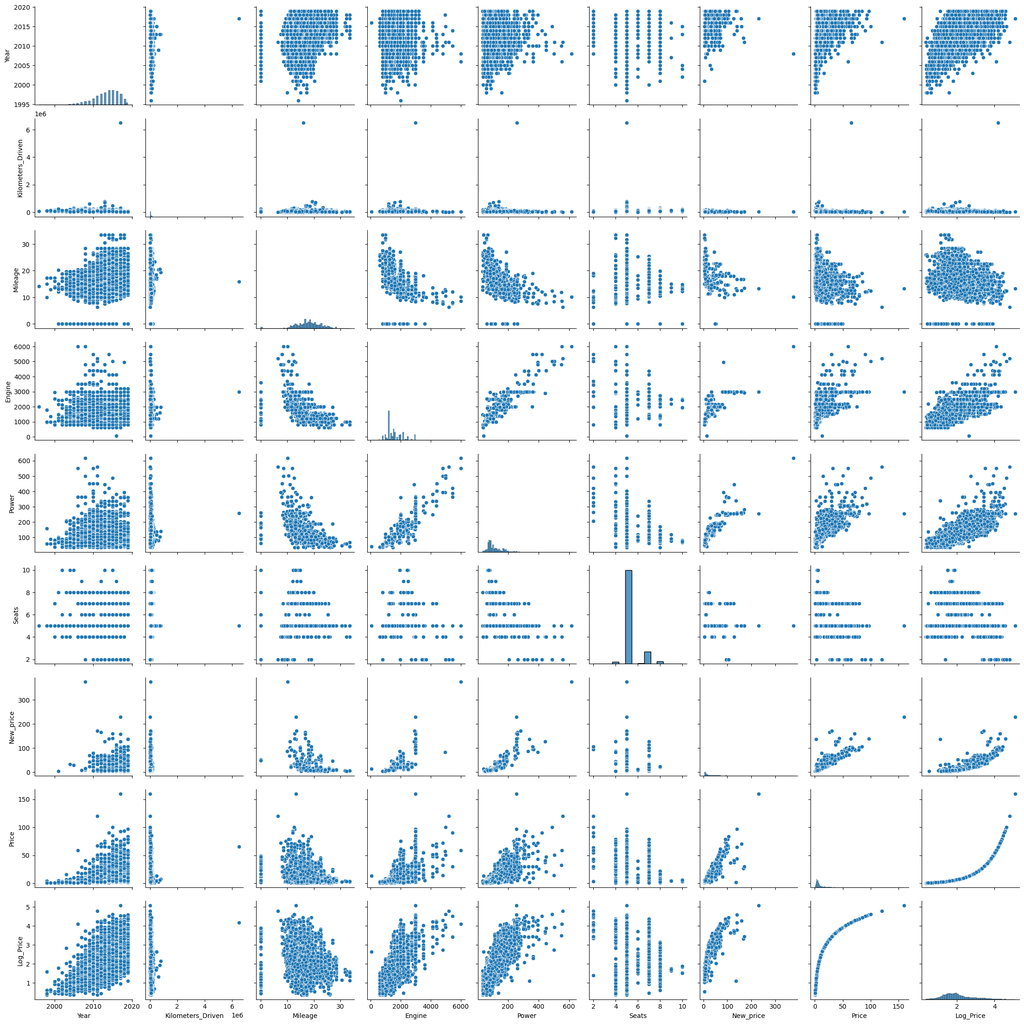

```python
import pandas as pd
import seaborn as sns
import matplotlib.pyplot as plt

# Load data from the CSV file
data = pd.read_csv("used_cars.csv")

# Calculate Log_Price and add it as a new column
data['Log_Price'] = data['Price'].apply(lambda x: np.log1p(x))

# List of features for the pair plot
features = ['Location', 'Year', 'Kilometers_Driven', 'Fuel_Type', 'Transmission', 'Owner_Type', 'Mileage', 'Engine', 'Power', 'Seats', 'New_price', 'Price', 'Log_Price']

# Create the pair plot
sns.pairplot(data[features])

# Show the plot
plt.show()
```

**Observations and Insights from all plots: According to above plots, we can find that there are some strong relation among some of them like the strong relation between "Engine and power" and power and log_price**

### **Heat map**

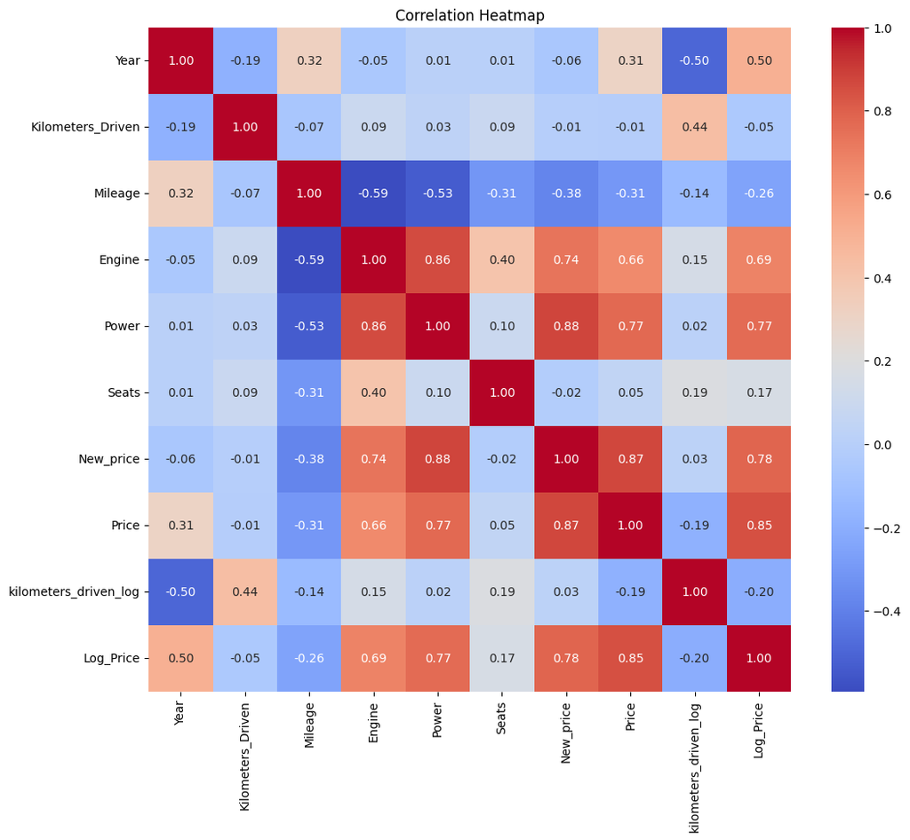

```python
# plt.show()
import pandas as pd
import seaborn as sns
import matplotlib.pyplot as plt
import math  # Import the math module

# Load data from the CSV file
data = pd.read_csv("used_cars.csv")

# Assuming you want to create these columns based on existing columns
# data['Log(power)'] = data['Power'].apply(lambda x: math.log(x))
data['kilometers_driven_log'] = data['Kilometers_Driven'].apply(lambda x: math.log(x))
data['Log_Price'] = data['Price'].apply(lambda x: math.log(x))

# Select the features for the heatmap
features = ['Year', 'Kilometers_Driven', 'Mileage', 'Engine', 'Power', 'Seats',
            'New_price', 'Price', 'kilometers_driven_log', 'Log_Price', 'Fuel_Type', 'Transmission', 'Owner_Type']

# Create a correlation matrix
correlation_matrix = data[features].corr()

# Plot the heatmap
plt.figure(figsize=(12, 10))
sns.heatmap(correlation_matrix, annot=True, cmap="coolwarm", fmt=".2f")
plt.title("Correlation Heatmap")
plt.show()
```

### **Box plot**

```python
def boxplot(z):

    plt.figure(figsize = (12, 5)) # Setting size of boxplot

    sns.boxplot(x = z, y = data['Price']) # Defining x and y

    plt.show()

    plt.figure(figsize = (12, 5))

    plt.title('Without Outliers')

    sns.boxplot(x = z, y = data['Price'], showfliers = False) # Turning off the outliers

    plt.show()
```

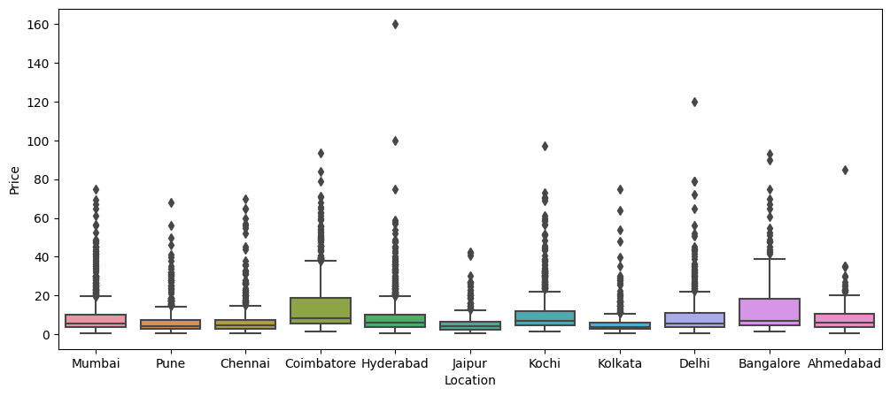

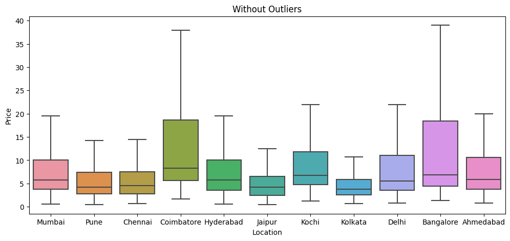

```python
boxplot(data['Location'])
```

**Observations and Insights for all plots:Percentage of outliers for Year: 0.80%, Percentage of outliers for Kilometers_Driven: 3.56%, Percentage of outliers for Mileage: 1.37%, Percentage of outliers for Engine: 0.90%, Percentage of outliers for Power: 3.86%, Percentage of outliers for Seats: 16.00%, Percentage of outliers for New_price: 10.74%, Percentage of outliers for Price: 11.93%**

### **Feature Engineering**

```python
data["Name"].nunique()
```

```
2041
```

```python
# Count the occurrences of each unique name
name_counts = data["Name"].value_counts()

# Calculate the percentage of occurrences for each unique name
name_percentages = (name_counts / len(data)) * 100

# Create a DataFrame to store the results
unique_name_stats = pd.DataFrame({"Name": name_counts.index, "Count": name_counts, "Percentage": name_percentages})

# Display the top unique names and their statistics
print(unique_name_stats.head(20))
```

```
                                                              Name  Count  \
Mahindra XUV500 W8 2WD                      Mahindra XUV500 W8 2WD     55
Maruti Swift VDI                                  Maruti Swift VDI     49
Maruti Swift Dzire VDI                      Maruti Swift Dzire VDI     42
Honda City 1.5 S MT                            Honda City 1.5 S MT     39
Maruti Swift VDI BSIV                        Maruti Swift VDI BSIV     37
Maruti Ritz VDi                                    Maruti Ritz VDi     35
Toyota Fortuner 3.0 Diesel              Toyota Fortuner 3.0 Diesel     35
Honda Amaze S i-Dtech                        Honda Amaze S i-Dtech     32
Hyundai Grand i10 Sportz                  Hyundai Grand i10 Sportz     32
Honda City 1.5 V MT                            Honda City 1.5 V MT     32
Honda Brio S MT                                    Honda Brio S MT     32
Hyundai i10 Sportz                              Hyundai i10 Sportz     31
Maruti Alto LXi                                    Maruti Alto LXi     30
Maruti Wagon R LXI                              Maruti Wagon R LXI     29
Maruti Ertiga VDI                                Maruti Ertiga VDI     28
Volkswagen Polo 1.2 MPI Highline  Volkswagen Polo 1.2 MPI Highline     26
Maruti Wagon R VXI                              Maruti Wagon R VXI     25
Hyundai EON Era Plus                          Hyundai EON Era Plus     25
Hyundai Verna 1.6 SX                          Hyundai Verna 1.6 SX     25
Toyota Fortuner 4x2 AT                      Toyota Fortuner 4x2 AT     23

                                  Percentage
Mahindra XUV500 W8 2WD              0.758307
Maruti Swift VDI                    0.675583
Maruti Swift Dzire VDI              0.579071
Honda City 1.5 S MT                 0.537709
Maruti Swift VDI BSIV               0.510134
Maruti Ritz VDi                     0.482559
Toyota Fortuner 3.0 Diesel          0.482559
Honda Amaze S i-Dtech               0.441197
Hyundai Grand i10 Sportz            0.441197
Honda City 1.5 V MT                 0.441197
Honda Brio S MT                     0.441197
Hyundai i10 Sportz                  0.427409
Maruti Alto LXi                     0.413622
Maruti Wagon R LXI                  0.399835
Maruti Ertiga VDI                   0.386047
Volkswagen Polo 1.2 MPI Highline    0.358472
Maruti Wagon R VXI                  0.344685
Hyundai EON Era Plus                0.344685
Hyundai Verna 1.6 SX                0.344685
Toyota Fortuner 4x2 AT              0.317110
```

With 2041 unique names, car names are not going to be great predictors of the price in our current data. But we can process this column to extract important information for example brand name.

```python
# Extract Brand Names
data["Brand"] = data["Name"].apply(lambda x: x.split(" ")[0].lower())
unique_brands = data["Brand"].unique()
print(unique_brands)
```

```
['maruti' 'hyundai' 'honda' 'audi' 'nissan' 'toyota' 'volkswagen' 'tata'
 'land' 'mitsubishi' 'renault' 'mercedes-benz' 'bmw' 'mahindra' 'ford'
 'porsche' 'datsun' 'jaguar' 'volvo' 'chevrolet' 'skoda' 'mini' 'fiat'
 'jeep' 'smart' 'ambassador' 'isuzu' 'force' 'bentley' 'lamborghini'
 'hindustan' 'opelcorsa']
```

```python
# Extract Model Names
data["Model"] = data["Name"].apply(lambda x: ' '.join(x.split(' ')[1:]))
unique_models = data["Model"].unique()
print(unique_models)
```

```
['Wagon R LXI CNG' 'Creta 1.6 CRDi SX Option' 'Jazz V' ...
 'EcoSport 1.5 Petrol Ambiente' 'Compass 1.4 Sport' 'Elite i20 Magna Plus']
```

```python
brands_of_interest = ['maruti', 'hyundai', 'honda', 'audi', 'nissan', 'toyota', 'volkswagen', 'tata',
                      'land', 'mitsubishi', 'renault', 'mercedes-benz', 'bmw', 'mahindra', 'ford',
                      'porsche', 'datsun', 'jaguar', 'volvo', 'chevrolet', 'skoda', 'mini', 'fiat',
                      'jeep', 'smart', 'ambassador', 'isuzu', 'force', 'bentley', 'lamborghini',
                      'hindustan', 'opelcorsa']

brand_counts = data[data["Brand"].isin(brands_of_interest)]["Brand"].value_counts()

highest_count_brand = brand_counts.idxmax()
highest_count = brand_counts.max()

print(f"The brand with the highest number of used cars is '{highest_count_brand}' with {highest_count} cars.")
```

```
The brand with the highest number of used cars is 'maruti' with 1444 cars.
```

#### **Observations and Insights: maruti has the highest trading among other brands. It means that Maruti is a repetitive brand in our dataset**

### **Missing value treatment**

```python
# Now check the missing values of each column. Hint: Use isnull() method
missing_values = data.isnull().sum()
print(missing_values)
```

```
S.No.                       0
Name                        0
Location                    0
Year                        0
Kilometers_Driven           0
Fuel_Type                   0
Transmission                0
Owner_Type                  0
Mileage                     2
Engine                     46
Power                     175
Seats                      53
New_price                6247
Price                    1234
kilometers_driven_log       0
Log_Price                1234
Brand                       0
Model                       0
dtype: int64
```

**Missing values in Seats**

```python
# Checking missing values in the column 'Seats'
missing_seats = data['Seats'].isnull().sum()
print("Number of missing values in 'Seats' column:", missing_seats)
```

```
Number of missing values in 'Seats' column: 53
```

```python
# Impute missing values in Seats,you can use fillna method in pandas
median_seats = data['Seats'].median()
data['Seats'].fillna(median_seats, inplace=True)
```

```python
# Now check total number of missing values of the seat column to verify if they are imputed or not. Hint: Use isnull() method
missing_values = data.isnull().sum()
print(missing_values)
```

```
S.No.                       0
Name                        0
Location                    0
Year                        0
Kilometers_Driven           0
Fuel_Type                   0
Transmission                0
Owner_Type                  0
Mileage                     2
Engine                     46
Power                     175
Seats                       0
New_price                6247
Price                    1234
kilometers_driven_log       0
Log_Price                1234
Brand                       0
Model                       0
dtype: int64
```

**Missing values for Mileage**

```python
# Now check missing values of each column. Hint: Use isnull() method
missing_mileage = data['Mileage'].isnull().sum()
print("Number of missing values in 'Mileage' column:", missing_mileage)
```

```
Number of missing values in 'Mileage' column: 2
```

```python
# Impute missing Mileage. For example, use can use median or any other methods.
median_mileage = data['Mileage'].median()
data['Mileage'].fillna(median_mileage, inplace=True)
```

```python
# Now check total number of missing values of the seat column to verify if they are imputed or not. Hint: Use isnull() method
missing_values = data.isnull().sum()
print(missing_values)
```

```
S.No.                       0
Name                        0
Location                    0
Year                        0
Kilometers_Driven           0
Fuel_Type                   0
Transmission                0
Owner_Type                  0
Mileage                     0
Engine                     46
Power                     175
Seats                       0
New_price                6247
Price                    1234
kilometers_driven_log       0
Log_Price                1234
Brand                       0
Model                       0
dtype: int64
```

**Missing values for Engine**

```python
# Impute missing values in the column Engine
median_engine = data['Engine'].median()
data['Engine'].fillna(median_engine, inplace=True)
```

**Missing values for Power**

```python
# Impute missing values in the column Power
median_power = data['Power'].median()
data['Power'].fillna(median_power, inplace=True)
```

**Missing values for New_price**

```python
# # Impute missing values in the column New_price
# data['New_price'].fillna('Unknown', inplace=True)
# # Remove the 'New_price' feature from X_train and X_test
# data.drop('New_price', axis=1, inplace=True)
```

```python
# Print the column names in the dataset
print(data.columns)
```

[output not shown]

```python
# Drop the rows where 'Price' == NaN
data.dropna(subset=['Price'], inplace=True)
```

```python
data.shape
```

```
(6019, 17)
```

```python
# data.dropna(subset=['Log_Price'], inplace=True)
```

```python
# Check the null values in the data
null_values = data.isnull().sum()
print(null_values)
```

[output not shown]

```python
data.shape
```

```
(6019, 17)
```

**Observations for missing values after imputing: After imputaing the missing values with a median, now we do not have any missing data**

## **Building Various Models**

1. What we want to predict is the "Price". We will use the normalized version 'price_log' for modeling.
2. Before we proceed to the model, we'll have to encode categorical features. We will drop categorical features like Name.
3. We'll split the data into train and test, to be able to evaluate the model that we build on the train data.
4. Build Regression models using train data.
5. Evaluate the model performance.

```python
X=data[['Year', 'Kilometers_Driven', 'Fuel_Type',
       'Transmission', 'Owner_Type', 'Mileage', 'Engine', 'Power', 'Seats','kilometers_driven_log', 'Brand','Model']]
y = data[['Log_Price', 'Price']]
```

```python
data.columns
```

```
Index(['S.No.', 'Name', 'Location', 'Year', 'Kilometers_Driven', 'Fuel_Type',
       'Transmission', 'Owner_Type', 'Mileage', 'Engine', 'Power', 'Seats',
       'Price', 'kilometers_driven_log', 'Log_Price', 'Brand', 'Model'],
      dtype='object')
```

```python
X.shape
```

```
(6019, 12)
```

```python
y
```

|  | Log_Price | Price |
| --- | --- | --- |
| 0 | 0.559616 | 1.75 |
| 1 | 2.525729 | 12.50 |
| 2 | 1.504077 | 4.50 |
| 3 | 1.791759 | 6.00 |
| 4 | 2.875822 | 17.74 |
| ... | ... | ... |
| 6014 | 1.558145 | 4.75 |
| 6015 | 1.386294 | 4.00 |
| 6016 | 1.064711 | 2.90 |
| 6017 | 0.974560 | 2.65 |
| 6018 | 0.916291 | 2.50 |

6019 rows × 2 columns

```python
data.shape
```

```
(6019, 17)
```

```python
feature_names = data.columns
print(feature_names)
```

```
Index(['S.No.', 'Name', 'Location', 'Year', 'Kilometers_Driven', 'Fuel_Type',
       'Transmission', 'Owner_Type', 'Mileage', 'Engine', 'Power', 'Seats',
       'Price', 'kilometers_driven_log', 'Log_Price', 'Brand', 'Model'],
      dtype='object')
```

```python
y.columns
```

```
Index(['Log_Price', 'Price'], dtype='object')
```

```python
missing_values = data.isna().sum()
print(missing_values)
```

```
S.No.                    0
Name                     0
Location                 0
Year                     0
Kilometers_Driven        0
Fuel_Type                0
Transmission             0
Owner_Type               0
Mileage                  0
Engine                   0
Power                    0
Seats                    0
Price                    0
kilometers_driven_log    0
Log_Price                0
Brand                    0
Model                    0
dtype: int64
```

```python
# Step-2 Use pd.get_dummies(drop_first = True)
X = pd.get_dummies(X, drop_first = True)
```

```python
#Splitting data into training and test set:
from sklearn.model_selection import train_test_split
X_train, X_test, y_train, y_test= train_test_split(X, y, test_size = 0.3, random_state = 1)
print(X_train.shape, X_test.shape)
```

```
(4213, 1919) (1806, 1919)
```

For Regression Problems, some of the algorithms used are :

**1) Linear Regression**  
**2) Ridge / Lasso Regression**  
**3) Decision Trees**  
**4) Random Forest**  
Note: All codes for ML sections have been embedded in the second python file